# Who is the next Italian CR7?

by Vito Fanelli

### 1. Scope

The purpose of this analysis is to identify the future Italian Cristiano Ronaldo. Young football players under 20 years old in 2017 are considered. The available data comes from the detailed database of the famous manager game for pc, Football Manager 2017.

### 2. Data

Dataset contains 4841 football players (not Goalkeeper) and 78 variables that characterize each player from a physical, technical-tactical and mental point of view with a value between 1 and 20.

```
'data.frame':   4841 obs. of  78 variables:
 $ Name               : chr  "Tullio Calabretta" "Simone Regoli" "Andrea Vedovati" "Francesco Serafino" ...
 $ AerialAbility      : int  2 1 1 3 1 2 4 1 1 1 ...
 $ CommandOfArea      : int  1 2 3 2 3 3 2 3 3 1 ...
 $ Communication      : int  2 1 1 3 1 3 2 2 3 1 ...
 $ Eccentricity       : int  3 2 3 3 1 3 1 1 1 2 ...
 $ Handling           : int  2 2 3 1 4 1 2 1 3 1 ...
 $ Kicking            : int  2 2 1 1 1 1 2 1 2 4 ...
 $ OneOnOnes          : int  2 1 1 2 1 1 2 2 2 2 ...
 $ Reflexes           : int  3 3 2 3 2 4 2 3 2 1 ...
 $ RushingOut         : int  2 1 2 3 1 3 3 1 2 4 ...
 $ TendencyToPunch    : int  1 2 3 1 1 2 1 2 2 4 ...
 $ Throwing           : int  1 3 2 2 1 2 1 4 1 3 ...
 $ Corners            : int  5 5 10 6 5 6 6 7 1 2 ...
 $ Crossing           : int  5 9 12 6 7 2 5 11 1 1 ...
```

[output cut: 64 more lines]

### 3. Cluster Analysis

To identify the young Italian football players most similar to Cristiano Ronaldo, based on the characteristics above, we use hierarchical cluster analysis, which is a statistical technique that creates groups (clusters) of observations (the football players in this case) that are similar to each other and different between one group and another. The Euclidean distance between their variables is used to determine the “similarity” or “dissimilarity” between two observations.

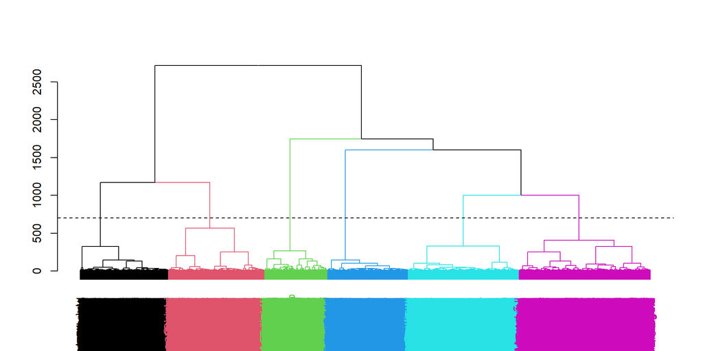

### 4. Results

We can observe 6 goups of players. The group that contains Cristiano Ronaldo is number 6, that contains other 534 players. Below is the distribution of cluster 6 by field position:

```
                                                Striker
                                                     68
                                        Defender Center
                                                     67
                                      Midfielder Center
                                                     47
                   DefenderMidfielder/Midfielder Center
                                                     40
                                 Defender/Wingback Left
                                                     25
                                Defender/Wingback Right
                                                     24
                                         Defender Right
                                                     20
                                   Defender RightCenter
                                                     20
                           AdvancedMidfielder RightLeft
                                                     16
                   AdvancedMidfielder/Striker RightLeft
                                                     13
                                    Defender LeftCenter
                                                      9
                      Defender/Wingback/Midfielder Left
                                                      9
                                 Midfielder RightCenter
                                                      9
                   Midfielder/AdvancedMidfielder Center
                                                      9
                        AdvancedMidfielder/Striker Left
                                                      8
                             Midfielder RightLeftCenter
                                                      8
                      AdvancedMidfielder/Striker Center
                                                      7
                  AdvancedMidfielder/Striker LeftCenter
                                                      7
                                          Defender Left
                                                      7
                            Defender/Wingback RightLeft
                                                      7
```

[output cut: 77 more lines]

```
                                                      1
                    DefenderMidfielder/Midfielder Right
                                                      1
                                      Striker RightLeft
                                                      1
      Wingback/DefenderMidfielder/Midfielder LeftCenter
                                                      1
     Wingback/DefenderMidfielder/Midfielder RightCenter
                                                      1
           Wingback/Midfielder/AdvancedMidfielder Right
                                                      1
     Wingback/Midfielder/AdvancedMidfielder RightCenter
                                                      1
       Wingback/Midfielder/AdvancedMidfielder RightLeft
                                                      1
```

The curious thing we notice is that many players in the cluster are defenders (central or outside) and midfielders … perhaps they unknowingly chose to play in the wrong role?

Let’s look at the average values of the main technical-tactical characteristics by cluster:

| cluster | Dribbling | Finishing | LongShots | Passing | Crossing | Marking | Tackle | Technique | Positioning | OffTheBall |
| --- | --- | --- | --- | --- | --- | --- | --- | --- | --- | --- |
| 1 | 8.326165 | 5.777778 | 5.231183 | 6.662186 | 8.296595 | 3.659498 | 4.589606 | 9.198029 | 3.723118 | 5.482079 |
| 2 | 9.342566 | 11.459184 | 3.938776 | 4.279883 | 3.000000 | 2.234694 | 1.565598 | 7.689504 | 2.915452 | 9.505831 |
| 3 | 4.164417 | 2.812270 | 3.474847 | 6.344785 | 4.537423 | 6.709202 | 10.088344 | 6.139877 | 6.710429 | 3.933742 |
| 4 | 3.515957 | 4.485106 | 6.786170 | 10.174468 | 3.764894 | 6.414894 | 7.504255 | 9.054255 | 5.332979 | 5.094681 |
| 5 | 1.518024 | 1.789052 | 2.116155 | 4.218959 | 1.620828 | 10.591455 | 9.983979 | 2.734312 | 10.361816 | 2.280374 |
| 6 | 8.143925 | 6.555140 | 7.207477 | 9.293458 | 7.457944 | 7.448598 | 8.342056 | 9.540187 | 8.601869 | 8.328972 |

Let us look at the average values of the main physical characteristics by cluster:

| cluster | Acceleration | Agility | Jumping | Stamina | Strength | LeftFoot | RightFoot |
| --- | --- | --- | --- | --- | --- | --- | --- |
| 1 | 12.527778 | 11.120072 | 6.888889 | 7.198925 | 6.139785 | 10.902330 | 15.84677 |
| 2 | 11.919825 | 10.451895 | 7.344023 | 6.205539 | 6.663265 | 8.214286 | 18.70554 |
| 3 | 12.630675 | 11.408589 | 7.954601 | 7.662577 | 7.272393 | 12.669939 | 14.09816 |
| 4 | 11.475532 | 10.557447 | 7.006383 | 7.230851 | 6.406383 | 7.868085 | 19.03298 |
| 5 | 9.991989 | 9.307076 | 9.307076 | 4.979973 | 7.726302 | 8.946596 | 17.88919 |
| 6 | 11.164486 | 10.637383 | 8.813084 | 10.041121 | 8.110280 | 10.747664 | 16.85234 |

Physically, cluster 5 emerges in elevation, confirming that they are central defenders. In acceleration and agility the clusters are equivalent. Cluster 6 emerges in endurance and strength.

Let’s look at the average values of the main mental characteristics by cluster:

| cluster | Aggression | Anticipation | Bravery | Concentration | Decisions | Determination | Leadership |
| --- | --- | --- | --- | --- | --- | --- | --- |
| 1 | 6.912186 | 5.191756 | 4.388889 | 4.216846 | 8.285842 | 5.609319 | 6.541219 |
| 2 | 6.540816 | 6.720117 | 4.067055 | 3.320700 | 7.467930 | 5.520408 | 5.957726 |
| 3 | 6.973006 | 6.119018 | 7.262577 | 6.869939 | 10.804908 | 5.292025 | 6.466258 |
| 4 | 6.871277 | 5.491489 | 4.603192 | 4.391489 | 10.758511 | 5.539362 | 6.139362 |
| 5 | 6.909212 | 6.711615 | 6.574099 | 5.451268 | 11.739653 | 5.313752 | 6.158879 |
| 6 | 10.244860 | 9.244860 | 9.171963 | 8.988785 | 9.334579 | 10.157009 | 7.031776 |

Mentally, cluster 6 dominates in all areas except decision making. So we can conclude that it is the group of soccer players mentally most similar to Cristiano Ronaldo and that mental characteristics are the decisive ones in this clustering. Probably, being soccer players with less than 20 years of age, barring some exceptions, the difference between them is made by mentality rather than technical or physical qualities.

The young Italian football player most similar to Cristiano Ronaldo in 2017 is Federico Bonazzoli.

```
                    [,1]                 [,2]
UID                 "43143486"           "  735216"
Name                "Federico Bonazzoli" "Cristiano Ronaldo"
NationID            "776"                "788"
Born                "21-05-1997"         "05-02-1985"
Age                 "19"                 "31"
IntCaps             "  0"                "133"
IntGoals            " 0"                 "61"
U21Caps             " 1"                 "10"
U21Goals            "0"                  "3"
Height              "192"                "186"
Weight              "79"                 "84"
AerialAbility       "3"                  "2"
CommandOfArea       "2"                  "1"
Communication       "1"                  "3"
Eccentricity        "2"                  "1"
Handling            "1"                  "3"
Kicking             "3"                  "2"
OneOnOnes           "1"                  "2"
Reflexes            "2"                  "3"
RushingOut          "4"                  "1"
TendencyToPunch     "3"                  "3"
Throwing            "1"                  "2"
Corners             " 7"                 "12"
Crossing            "10"                 "14"
Dribbling           "11"                 "15"
Finishing           "13"                 "19"
FirstTouch          "12"                 "16"
Freekicks           "11"                 "14"
Heading             "12"                 "18"
LongShots           "12"                 "19"
Longthrows          "6"                  "6"
Marking             "6"                  "2"
Passing             " 9"                 "14"
PenaltyTaking       "14"                 "19"
Tackling            "7"                  "8"
Technique           "12"                 "15"
Aggression          "12"                 " 6"
Anticipation        "11"                 "17"
Bravery             "11"                 "16"
```

[output cut: 37 more lines]

```
Striker             "20"                 "19"
AttackingMidCentral "11"                 " 8"
AttackingMidLeft    "11"                 "20"
AttackingMidRight   "14"                 "15"
DefenderCentral     "1"                  "1"
DefenderLeft        "1"                  "1"
DefenderRight       "1"                  "1"
DefensiveMidfielder "1"                  "1"
MidfielderCentral   "1"                  "1"
MidfielderLeft      " 1"                 "15"
MidfielderRight     " 1"                 "10"
WingBackLeft        "1"                  "1"
WingBackRight       "1"                  "1"
Role                "Striker"            "AdvancedMidfielder/Striker RightLeft"
cluster             "6"                  "6"
```